# Analysis of Animal Rescues (tidytuesday)

# 🐾 Building complex model 🐾

In this section I will investigate what other factors influence rescue cost with a more complex linear regression model.

Outcome: incident_notional_cost

In the more complex model, I will include the following **predictors**:  
- day_or_night: computed from date_time_of_call (0: day, 1: night);  
- pump_count: number of trucks needed for the rescue;  
- pump_hours_total: length of rescue operation;  
- domestic_wild: computed from animal_group_parent (0: domestic; 1: wild);  
- borough_inner_outer: computed from borough (0: inner; 1: outer).

## Fitting complex model

```r
complexmodel <- lm(incident_notional_cost ~ day_or_night + pump_count + pump_hours_total + domestic_wild + borough_inner_outer, data = animal_rescues_interest)
```

## Extracting statistics and coefficients of complex model, computing standardized coefficients

```r
# Model statistics
glance(complexmodel)
```

```
## # A tibble: 1 × 12
##   r.squared adj.r.squared sigma statistic p.value    df  logLik    AIC    BIC
##       <dbl>         <dbl> <dbl>     <dbl>   <dbl> <dbl>   <dbl>  <dbl>  <dbl>
## 1     0.948         0.948  45.0    25781.       0     5 -37271. 74557. 74605.
## # ℹ 3 more variables: deviance <dbl>, df.residual <int>, nobs <int>
```

```r
#Coefficients
summary(complexmodel)
```

```
##
## Call:
## lm(formula = incident_notional_cost ~ day_or_night + pump_count +
##     pump_hours_total + domestic_wild + borough_inner_outer, data = animal_rescues_interest)
##
## Residuals:
##     Min      1Q  Median      3Q     Max
## -329.74  -37.62   -2.00   33.66  380.66
##
## Coefficients:
##                      Estimate Std. Error t value Pr(>|t|)
## (Intercept)           30.0074     4.0442   7.420 1.31e-13 ***
## day_or_night           2.3396     1.1339   2.063   0.0391 *
## pump_count           -36.1792     4.5447  -7.961 1.98e-15 ***
## pump_hours_total     303.7875     1.0979 276.695  < 2e-16 ***
## domestic_wild1        11.8428     1.1781  10.053  < 2e-16 ***
## borough_inner_outer1  -0.6124     1.0900  -0.562   0.5742
## ---
## Signif. codes:  0 '***' 0.001 '**' 0.01 '*' 0.05 '.' 0.1 ' ' 1
##
## Residual standard error: 45 on 7127 degrees of freedom
## Multiple R-squared:  0.9476, Adjusted R-squared:  0.9476
## F-statistic: 2.578e+04 on 5 and 7127 DF,  p-value: < 2.2e-16
```

```r
tidy(complexmodel, conf.int = TRUE)
```

```
## # A tibble: 6 × 7
##   term                 estimate std.error statistic  p.value conf.low conf.high
##   <chr>                   <dbl>     <dbl>     <dbl>    <dbl>    <dbl>     <dbl>
## 1 (Intercept)            30.0        4.04     7.42  1.31e-13   22.1       37.9
## 2 day_or_night            2.34       1.13     2.06  3.91e- 2    0.117      4.56
## 3 pump_count            -36.2        4.54    -7.96  1.98e-15  -45.1      -27.3
## 4 pump_hours_total      304.         1.10   277.    0         302.       306.
## 5 domestic_wild1         11.8        1.18    10.1   1.29e-23    9.53      14.2
## 6 borough_inner_outer1   -0.612      1.09    -0.562 5.74e- 1   -2.75       1.52
```

```r
# Computing standardized beta coefficients
complexmodel_standardized <- lm.beta(complexmodel)
coef(complexmodel_standardized)
```

```
##          (Intercept)         day_or_night           pump_count
##                   NA          0.005615881         -0.028498093
##     pump_hours_total       domestic_wild1 borough_inner_outer1
##          0.992759033          0.027345966         -0.001527617
```

## Extracting specific model test statistics of complex model and putting them into a table

```r
adjusted_r2_complexmodel <- glance(complexmodel) %>% pull(adj.r.squared)
f_statistic_complexmodel <- glance(complexmodel) %>% pull(statistic)
p_value_complexmodel <- glance(complexmodel) %>% pull(p.value)
df_complexmodel <- glance(complexmodel) %>% pull(df)
AIC_complexmodel <- glance(complexmodel) %>% pull(AIC)

model_stats_complexmodel <- tibble(
  Statistic = c("Adjusted R-squared", "F-statistic", "p-value", "Degrees of Freedom", "AIC"),
  Value = c(adjusted_r2_complexmodel, f_statistic_complexmodel, p_value_complexmodel, df_complexmodel, AIC_complexmodel))

print(model_stats_complexmodel)
```

```
## # A tibble: 5 × 2
##   Statistic              Value
##   <chr>                  <dbl>
## 1 Adjusted R-squared     0.948
## 2 F-statistic        25781.
## 3 p-value                0
## 4 Degrees of Freedom     5
## 5 AIC                74557.
```

## Extracting coefficients of complex model and putting them into a table

```r
standardized_coefficients_complexmodel <- (coef(complexmodel_standardized))[-1]

coeff_extracted_complexmodel <- tidy(complexmodel, conf.int = TRUE) %>%
  select(term, estimate, conf.low, conf.high, p.value) %>%
  mutate(standardized = c(NA, standardized_coefficients_complexmodel))

print(coeff_extracted_complexmodel)
```

```
## # A tibble: 6 × 6
##   term                 estimate conf.low conf.high  p.value standardized
##   <chr>                   <dbl>    <dbl>     <dbl>    <dbl>        <dbl>
## 1 (Intercept)            30.0     22.1       37.9  1.31e-13     NA
## 2 day_or_night            2.34     0.117      4.56 3.91e- 2      0.00562
## 3 pump_count            -36.2    -45.1      -27.3  1.98e-15     -0.0285
## 4 pump_hours_total      304.     302.       306.   0             0.993
## 5 domestic_wild1         11.8      9.53      14.2  1.29e-23      0.0273
## 6 borough_inner_outer1   -0.612   -2.75       1.52 5.74e- 1     -0.00153
```

## Checking the model

### Cook’s distance for complex model and checking for influential outliers (Cook’s distance > 1)

```r
cooks_distance_complexmodel <- cooks.distance(complexmodel)
influential_outliers_complexmodel <- which(cooks_distance_complexmodel > 1)
influential_outliers_complexmodel
```

```
## named integer(0)
```

```r
# There are no influential outliers according to the test.
```

### Q-Q plot for residual normality check

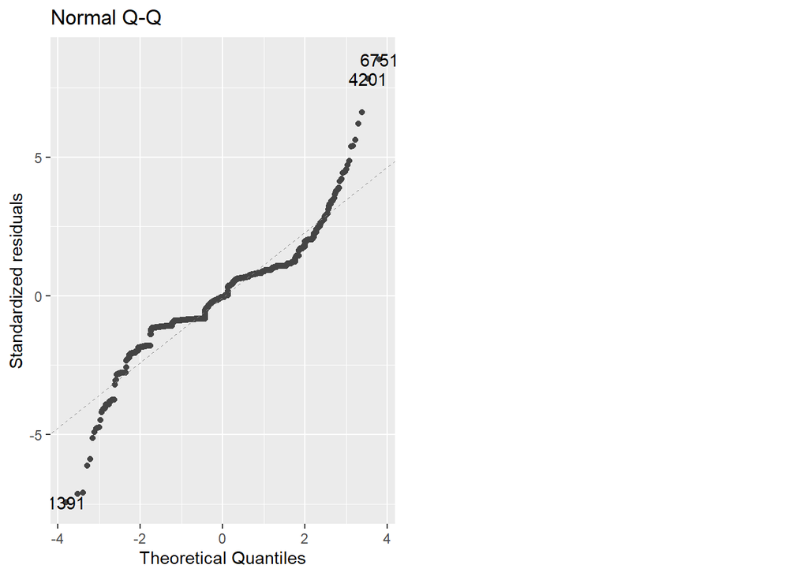

```r
autoplot(complexmodel, which = 2)
```

```r
# The plot shows that residuals are not normally distributed.

# Computing leverage values and checking leverage for specific observations that deviate from the Q-Q plot line
leverage_values <- hatvalues(complexmodel)
leverage_values[c(1391, 6751, 4201)]
```

```
##       1391       6751       4201
## 0.02819843 0.01604655 0.04124581
```

```r
## Viewing observations that might be influential
animal_rescues_interest[1391, ]
```

```
## # A tibble: 1 × 14
##   date_time_of_call   cal_year pump_count pump_hours_total
##   <dttm>                 <dbl>      <dbl>            <dbl>
## 1 2011-06-29 21:04:00     2011          3                9
## # ℹ 10 more variables: incident_notional_cost <dbl>, animal_group_parent <fct>,
## #   borough <fct>, day_or_night <dbl>, day_or_night_forplots <fct>,
## #   domestic_wild <fct>, domestic_wild_forplots <fct>,
## #   borough_inner_outer <fct>, borough_inner_outer_forplots <fct>,
## #   log_incident_notional_cost <dbl>
```

```r
animal_rescues_interest[6751, ]
```

```
## # A tibble: 1 × 14
##   date_time_of_call   cal_year pump_count pump_hours_total
##   <dttm>                 <dbl>      <dbl>            <dbl>
## 1 2020-11-15 13:47:00     2020          2                8
## # ℹ 10 more variables: incident_notional_cost <dbl>, animal_group_parent <fct>,
## #   borough <fct>, day_or_night <dbl>, day_or_night_forplots <fct>,
## #   domestic_wild <fct>, domestic_wild_forplots <fct>,
## #   borough_inner_outer <fct>, borough_inner_outer_forplots <fct>,
## #   log_incident_notional_cost <dbl>
```

```r
animal_rescues_interest[4201, ]
```

```
## # A tibble: 1 × 14
##   date_time_of_call   cal_year pump_count pump_hours_total
##   <dttm>                 <dbl>      <dbl>            <dbl>
## 1 2016-07-28 13:49:00     2016          3               12
## # ℹ 10 more variables: incident_notional_cost <dbl>, animal_group_parent <fct>,
## #   borough <fct>, day_or_night <dbl>, day_or_night_forplots <fct>,
## #   domestic_wild <fct>, domestic_wild_forplots <fct>,
## #   borough_inner_outer <fct>, borough_inner_outer_forplots <fct>,
## #   log_incident_notional_cost <dbl>
```

```r
### A horse, a deer and a cat with high rescue costs.
```

### Residuals vs. fitted plot to check linearity and homoskedasticity

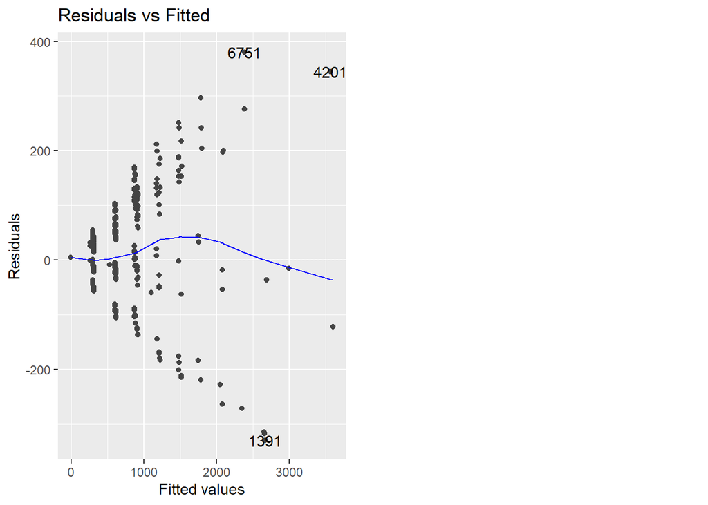

```r
autoplot(complexmodel, which = 1)
```

```r
# The bumpy line suggests that linearity is violated.
# The fanning pattern suggests that homoskedasticity is also violated.
```

### Independence of residuals (Durbin-Watson test)

```r
dwtest(complexmodel)
```

```
##
##  Durbin-Watson test
##
## data:  complexmodel
## DW = 0.467, p-value < 2.2e-16
## alternative hypothesis: true autocorrelation is greater than 0
```

```r
# Positive autocorrelation between residuals.
```

### Calculating VIF values for complex model

```r
vif(complexmodel)
```

```
##        day_or_night          pump_count    pump_hours_total       domestic_wild
##            1.007624            1.743329            1.751184            1.006655
## borough_inner_outer
##            1.005628
```

```r
# VIF < 5, so these are okay
```

The assumption checks still don’t look nice, so I will try the log-transformation with the complex model too.

## Fitting log-transformed complex model

```r
complexmodel_log <- lm(log_incident_notional_cost ~ day_or_night + pump_count + pump_hours_total + domestic_wild + borough_inner_outer, data = animal_rescues_interest)
```

## Extracting statistics and coefficients of log-transformed complex model, computing standardized coefficients

```r
# Model statistics
glance(complexmodel_log)
```

```
## # A tibble: 1 × 12
##   r.squared adj.r.squared sigma statistic p.value    df logLik    AIC    BIC
##       <dbl>         <dbl> <dbl>     <dbl>   <dbl> <dbl>  <dbl>  <dbl>  <dbl>
## 1     0.762         0.762 0.161     4562.       0     5  2916. -5818. -5770.
## # ℹ 3 more variables: deviance <dbl>, df.residual <int>, nobs <int>
```

```r
#Coefficients
summary(complexmodel_log)
```

```
##
## Call:
## lm(formula = log_incident_notional_cost ~ day_or_night + pump_count +
##     pump_hours_total + domestic_wild + borough_inner_outer, data = animal_rescues_interest)
##
## Residuals:
##     Min      1Q  Median      3Q     Max
## -5.2326 -0.1469 -0.0110  0.0962  0.5718
##
## Coefficients:
##                       Estimate Std. Error t value Pr(>|t|)
## (Intercept)           5.483789   0.014455 379.376  < 2e-16 ***
## day_or_night          0.004003   0.004053   0.988    0.323
## pump_count           -0.258688   0.016244 -15.925  < 2e-16 ***
## pump_hours_total      0.486358   0.003924 123.939  < 2e-16 ***
## domestic_wild1        0.031135   0.004211   7.394 1.59e-13 ***
## borough_inner_outer1  0.003484   0.003896   0.894    0.371
## ---
## Signif. codes:  0 '***' 0.001 '**' 0.01 '*' 0.05 '.' 0.1 ' ' 1
##
## Residual standard error: 0.1608 on 7127 degrees of freedom
## Multiple R-squared:  0.7619, Adjusted R-squared:  0.7618
## F-statistic:  4562 on 5 and 7127 DF,  p-value: < 2.2e-16
```

```r
tidy(complexmodel_log, conf.int = TRUE)
```

```
## # A tibble: 6 × 7
##   term                 estimate std.error statistic  p.value conf.low conf.high
##   <chr>                   <dbl>     <dbl>     <dbl>    <dbl>    <dbl>     <dbl>
## 1 (Intercept)           5.48      0.0145    379.    0         5.46       5.51
## 2 day_or_night          0.00400   0.00405     0.988 3.23e- 1 -0.00394    0.0119
## 3 pump_count           -0.259     0.0162    -15.9   3.90e-56 -0.291     -0.227
## 4 pump_hours_total      0.486     0.00392   124.    0         0.479      0.494
## 5 domestic_wild1        0.0311    0.00421     7.39  1.59e-13  0.0229     0.0394
## 6 borough_inner_outer1  0.00348   0.00390     0.894 3.71e- 1 -0.00415    0.0111
```

```r
# Computing standardized beta coefficients
complexmodel_log_standardized <- lm.beta(complexmodel_log)
coef(complexmodel_log_standardized)
```

```
##          (Intercept)         day_or_night           pump_count
##                   NA          0.005730210         -0.121525454
##     pump_hours_total       domestic_wild1 borough_inner_outer1
##          0.947903621          0.042876400          0.005183146
```